# HW3

Steven Xia 2/27/2021

[My Github Repo Here](https://github.com/sxia35/Homework3---Stat433.git)

```r
#install.packages("nycflights13")
library(nycflights13)
library(ggplot2)
library(tidyr)
```

In r4ds flights… What time of day should you fly if you want to avoid delays as much as possible? Does this choice depend on anything? Season? Weather? Airport? Airline? Find three patterns (“null results” are ok!). Write your results into Rmarkdown. Include a short introduction that summarizes the three results. Then, have a section for each finding. Support each finding with data summaries and visualizations. Include your code when necessary. This shouldn’t be long, but it might take some time to find the things you want to talk about and lay them out in an orderly way.

```r
head(flights)
```

```
## # A tibble: 6 x 19
##    year month   day dep_time sched_dep_time dep_delay arr_time sched_arr_time
##   <int> <int> <int>    <int>          <int>     <dbl>    <int>          <int>
## 1  2013     1     1      517            515         2      830            819
## 2  2013     1     1      533            529         4      850            830
## 3  2013     1     1      542            540         2      923            850
## 4  2013     1     1      544            545        -1     1004           1022
## 5  2013     1     1      554            600        -6      812            837
## 6  2013     1     1      554            558        -4      740            728
## # … with 11 more variables: arr_delay <dbl>, carrier <chr>, flight <int>,
## #   tailnum <chr>, origin <chr>, dest <chr>, air_time <dbl>, distance <dbl>,
## #   hour <dbl>, minute <dbl>, time_hour <dttm>
```

### Part 1 - What time of day should you fly if you want to avoid delays as much as possible?

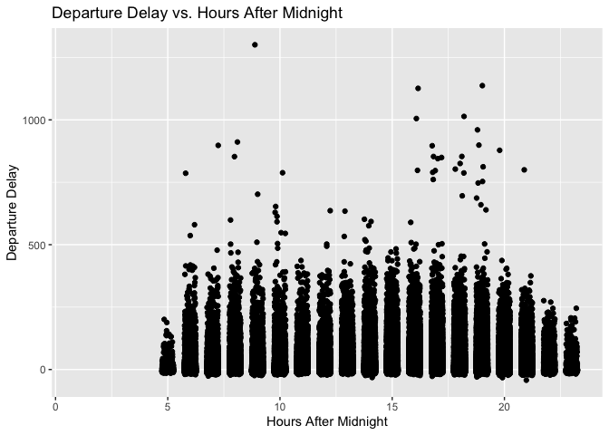

```r
flights %>%
  ggplot(aes(x = hour, y = dep_delay)) +
  geom_jitter(width = 0.25) +
  labs(
    x = "Hours After Midnight",
    y = "Departure Delay",
    title = "Departure Delay vs. Hours After Midnight")
```

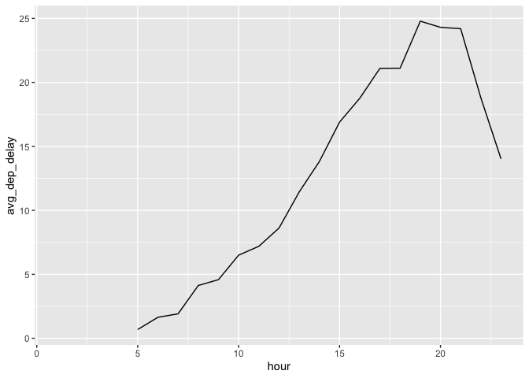

```r
flights %>%
  group_by(hour) %>%
  summarise(
    avg_dep_delay = mean(dep_delay, na.rm = T)
  ) %>%
  ggplot(aes(x = hour,y = avg_dep_delay)) +
  geom_line()
```

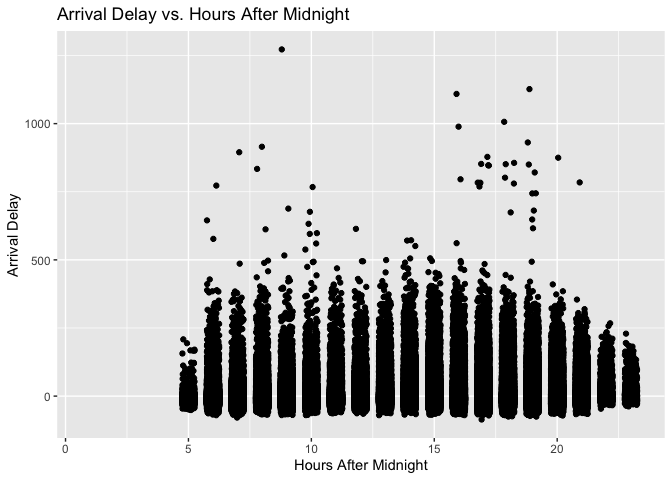

```r
flights %>%
  ggplot(aes(x = hour, y = arr_delay)) +
  geom_jitter(width = 0.25) +
  labs(
    x = "Hours After Midnight",
    y = "Arrival Delay",
    title = "Arrival Delay vs. Hours After Midnight")
```

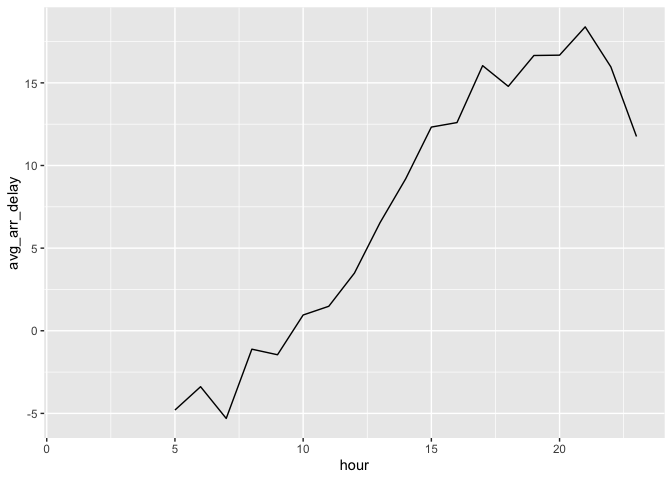

```r
flights %>%
  group_by(hour) %>%
  summarise(
    avg_arr_delay = mean(arr_delay, na.rm = T)
  ) %>%
  ggplot(aes(x = hour,y = avg_arr_delay)) +
  geom_line()
```

### Part 2 - Does this choice depend on anything? Season? Weather? Airport? Airline? Find three patterns

**Below, I have made several visualizations showing three patterns in which optimal flying time to avoid delays depends on: Season, Airport, and Airline. When either of these three variables change, the best time window to fly in order to avoid delays will change as well.**

## Pattern 1 - Season

**Upon observation, we can see that departure and arrival delays are at the highest levels during the summer months, particularly June-July. This is most likely due to people traveling/on vacation during time in which they are free from school/work. As we can see, during the summer months June-July, the average arrival and departure delays increase much faster, with hours 11AM-3PM being filled with many more departure and arrival delays. Thus, the best time to fly during the summer would be in the early morning.**

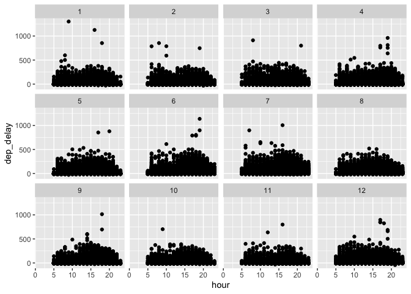

```r
ggplot(flights) +
  geom_point(aes(x = hour, y = dep_delay)) +
  facet_wrap(~month)
```

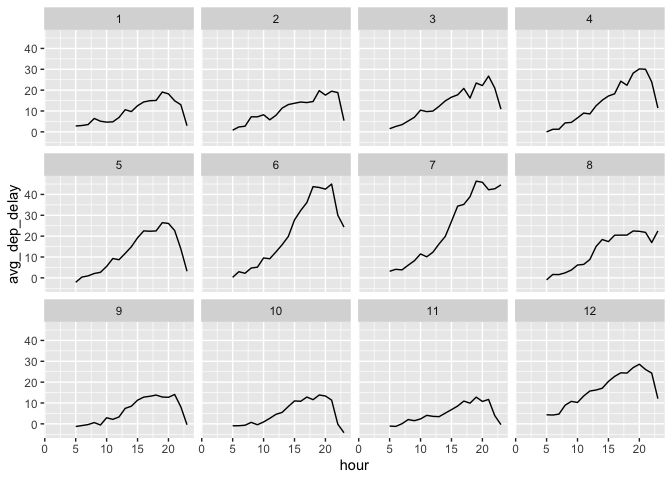

```r
flights %>%
  group_by(hour, month) %>%
  summarise(
    avg_dep_delay = mean(dep_delay, na.rm = T)
  ) %>%
  ggplot(aes(x = hour,y = avg_dep_delay)) +
  geom_line() +
  facet_wrap(~month)
```

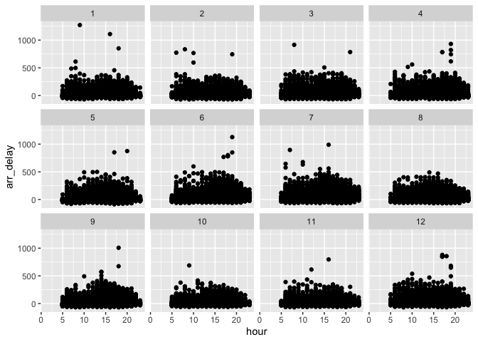

```r
ggplot(flights) +
  geom_point(aes(x = hour, y = arr_delay)) +
  facet_wrap(~month)
```

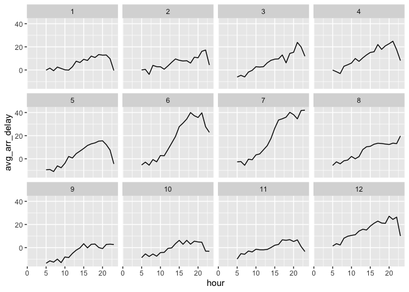

```r
flights %>%
  group_by(hour, month) %>%
  summarise(
    avg_arr_delay = mean(arr_delay, na.rm = T)
  ) %>%
  ggplot(aes(x = hour,y = avg_arr_delay)) +
  geom_line() +
  facet_wrap(~month)
```

## Pattern 2 - Airport

**As we can see from the figures below, EWR Airport appears to increase to the highest level of average delay throughout the day among all three airports. Average departure and arrival delays for EWR Airport increase at the fastest rate throughout the day as well. However, if we examine JFK and LGA Airports, they do not seem to reach as high of a peak delay throughout the day, so flyers should avoid EWR Airport and choose JFK or LGA.**

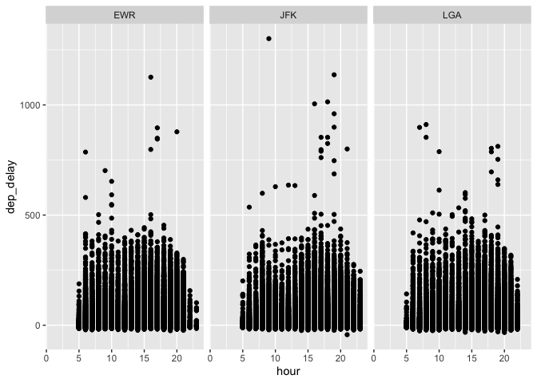

```r
ggplot(flights) +
  geom_point(aes(x = hour, y = dep_delay)) +
  facet_wrap(~origin)
```

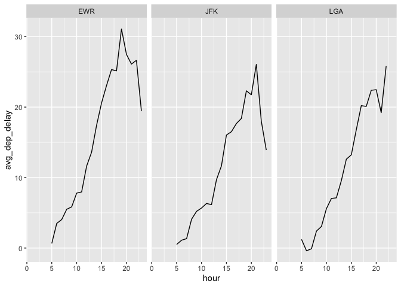

```r
flights %>%
  group_by(hour, origin) %>%
  summarise(
    avg_dep_delay = mean(dep_delay, na.rm = T)
  ) %>%
  ggplot(aes(x = hour,y = avg_dep_delay)) +
  geom_line() +
  facet_wrap(~origin)
```

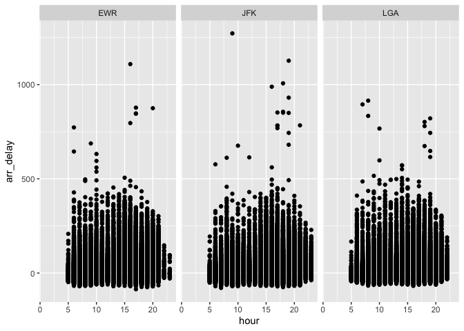

```r
ggplot(flights) +
  geom_point(aes(x = hour, y = arr_delay)) +
  facet_wrap(~origin)
```

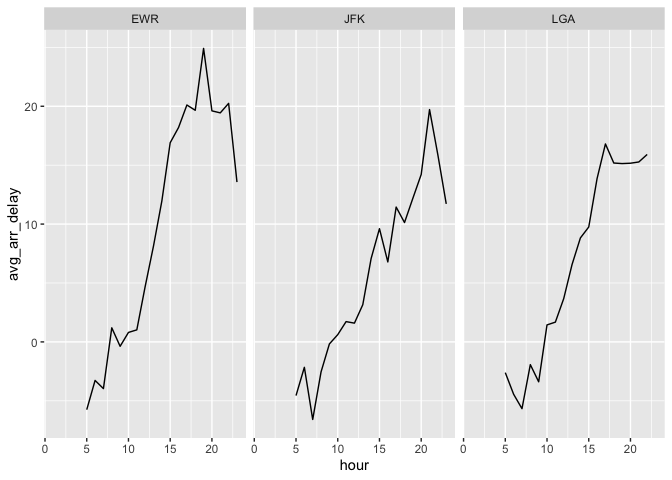

```r
flights %>%
  group_by(hour, origin) %>%
  summarise(
    avg_arr_delay = mean(arr_delay, na.rm = T)
  ) %>%
  ggplot(aes(x = hour,y = avg_arr_delay)) +
  geom_line() +
  facet_wrap(~origin)
```

## Pattern 3 - Airline

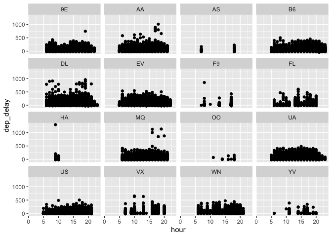

```r
ggplot(flights) +
  geom_point(aes(x = hour, y = dep_delay)) +
  facet_wrap(~carrier)
```

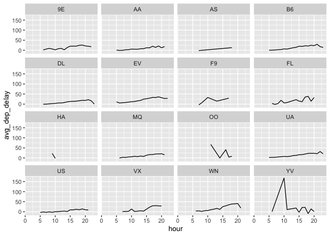

```r
flights %>%
  group_by(hour, carrier) %>%
  summarise(
    avg_dep_delay = mean(dep_delay, na.rm = T)
  ) %>%
  ggplot(aes(x = hour,y = avg_dep_delay)) +
  geom_line() +
  facet_wrap(~carrier)
```

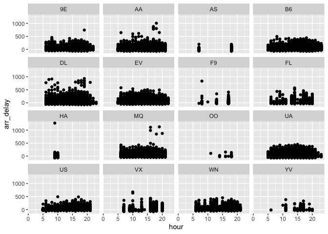

```r
ggplot(flights) +
  geom_point(aes(x = hour, y = arr_delay)) +
  facet_wrap(~carrier)
```

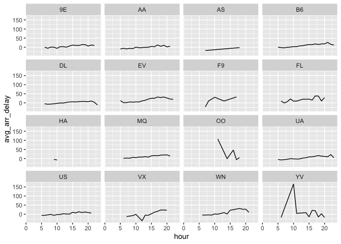

```r
flights %>%
  group_by(hour, carrier) %>%
  summarise(
    avg_arr_delay = mean(arr_delay, na.rm = T)
  ) %>%
  ggplot(aes(x = hour,y = avg_arr_delay)) +
  geom_line() +
  facet_wrap(~carrier)
```